# 防跌倒扶手调研数据聚类分析

K-means聚类方法

## 一、数据加载与检查

### 1.1 加载数据集

加载预处理后的子女和老年人数据集，确保数据文件存在且路径正确。

## 二、子女群体聚类分析

### 2.1 变量筛选与预处理

选择子女群体的相关变量，**仅剔除序号，其余全部纳入聚类**，确保数据类型正确。

### 2.2 变量标准化

对子女群体的所有变量进行标准化处理，确保不同变量的量纲一致，提高聚类效果。

### 2.3 确定最佳K值（轮廓系数法）

使用轮廓系数法自动选择最佳聚类数k，通过计算不同k值的轮廓系数并选择最大值对应的k。

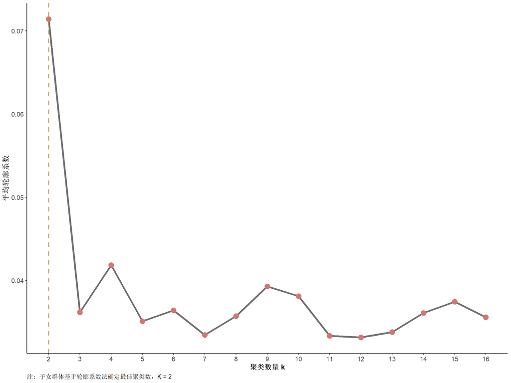

### 2.4 执行K-means聚类

使用自动选择的最佳k值执行K-means聚类，并将聚类标签与原始数据绑定。

### 2.5 聚类结果分析

分析子女群体的聚类结果，生成特征剖面表格，展示不同聚类的特征差异。

子女群体聚类特征剖面

K-means聚类方法

| 特征 | 1 | 2 |
| --- | --- | --- |
| 样本量 | 226.000 | 172.000 |
| 问卷总分_C | 92.394 | 72.395 |
| 性别_男_1_1_C | 0.518 | 0.541 |
| 年龄_18-24岁_1_2_1_C | 0.257 | 0.273 |
| 年龄_25-34岁_1_2_2_C | 0.248 | 0.250 |
| 年龄_35-44岁_1_2_3_C | 0.292 | 0.238 |
| 年龄_45-54岁_1_2_4_C | 0.177 | 0.151 |
| 年龄_55岁及以上_1_2_5_C | 0.027 | 0.087 |
| 与老人居住关系_同住_1_3_1_C | 0.279 | 0.320 |
| 与老人居住关系_同城不同住_1_3_2_C | 0.442 | 0.395 |
| 与老人居住关系_异地居住_1_3_3_C | 0.279 | 0.285 |
| 老人年龄_60-64岁_1_4_1_C | 0.111 | 0.215 |
| 老人年龄_65-74岁_1_4_2_C | 0.243 | 0.279 |
| 老人年龄_75-84岁_1_4_3_C | 0.394 | 0.279 |
| 老人年龄_85岁及以上_1_4_4_C | 0.252 | 0.227 |
| 老人健康状况_失能程度_1_5_C | 1.912 | 1.674 |
| 居住行政区_和平区_1_6_1_C | 0.155 | 0.145 |
| 居住行政区_南开区_1_6_2_C | 0.164 | 0.134 |
| 居住行政区_河北区_1_6_3_C | 0.208 | 0.233 |
| 居住行政区_河东区_1_6_4_C | 0.226 | 0.174 |
| 居住行政区_河西区_1_6_5_C | 0.195 | 0.227 |
| 居住行政区_红桥区_1_6_6_C | 0.053 | 0.087 |
| 为老人装过扶手_是_1_7_C | 0.381 | 0.390 |
| 扶手安装场景_卫生间_2_1_1_C | 0.912 | 0.890 |
| 扶手安装场景_床边_2_1_2_C | 0.429 | 0.384 |
| 扶手安装场景_楼道_2_1_3_C | 0.779 | 0.779 |
| 扶手安装场景_阳台_2_1_4_C | 0.487 | 0.500 |
| 扶手安装场景_其他_2_1_5_C | 0.173 | 0.157 |
| 扶手偏好类型_基础不锈钢_2_2_1_C | 0.195 | 0.198 |
| 扶手偏好类型_可折叠_2_2_2_C | 0.235 | 0.209 |
| 扶手偏好类型_防滑_2_2_3_C | 0.363 | 0.413 |
| 扶手偏好类型_智能预警_2_2_4_C | 0.093 | 0.116 |
| 扶手偏好类型_其他_2_2_5_C | 0.115 | 0.076 |
| 可接受价格_100元以内_2_3_1_C | 0.150 | 0.052 |
| 可接受价格_100-300元_2_3_2_C | 0.372 | 0.355 |
| 可接受价格_300-500元_2_3_3_C | 0.292 | 0.384 |
| 可接受价格_500元以上_2_3_4_C | 0.106 | 0.070 |
| 可接受价格_无所谓_2_3_5_C | 0.080 | 0.140 |
| 服务期望_免费安装_2_4_1_C | 0.850 | 0.797 |
| 服务期望_24小时售后_2_4_2_C | 0.438 | 0.390 |
| 服务期望_定期维护_2_4_3_C | 0.717 | 0.663 |
| 服务期望_上门教学_2_4_4_C | 0.566 | 0.512 |
| 服务期望_其他_2_4_5_C | 0.173 | 0.192 |
| 照护价值_3_1_1_C | 4.004 | 3.047 |
| 照护价值_3_1_2_C | 4.049 | 3.256 |
| 照护价值_3_1_3_C | 4.009 | 3.017 |
| 照护价值_3_1_4_C | 4.044 | 3.035 |
| 代际责任_3_2_1_C | 4.252 | 3.227 |
| 代际责任_3_2_2_C | 4.243 | 3.238 |
| 代际责任_3_2_3_C | 4.288 | 3.366 |
| 代际责任_3_2_4_C | 4.212 | 3.186 |
| 决策便利_3_3_1_C | 3.845 | 2.948 |
| 决策便利_3_3_2_C | 3.920 | 3.081 |
| 决策便利_3_3_3_C | 3.858 | 2.878 |
| 决策便利_3_3_4_C | 3.894 | 2.959 |
| 资源投入_3_4_1_C | 4.097 | 3.320 |
| 资源投入_3_4_2_C | 4.000 | 3.227 |
| 资源投入_3_4_3_C | 4.053 | 3.128 |
| 资源投入_3_4_4_C | 4.088 | 3.157 |
| 认知偏差_3_5_1_C | 3.695 | 3.407 |
| 认知偏差_3_5_2_C | 3.743 | 3.279 |
| 认知偏差_3_5_3_C | 3.730 | 3.285 |
| 认知偏差_3_5_4_C | 3.695 | 3.221 |
| 购买意愿_3_6_1_C | 4.310 | 2.988 |
| 购买意愿_3_6_2_C | 4.186 | 3.023 |
| 购买意愿_3_6_3_C | 4.177 | 3.122 |

## 三、老年人群体聚类分析

### 3.1 变量筛选与预处理

选择老年人群体的相关变量，**仅剔除序号，其余全部纳入聚类**，确保数据类型正确。

### 3.2 变量标准化

对老年人群体的所有变量进行标准化处理，确保不同变量的量纲一致，提高聚类效果。

### 3.3 确定最佳K值（轮廓系数法）

使用轮廓系数法自动选择最佳聚类数k，通过计算不同k值的轮廓系数并选择最大值对应的k。

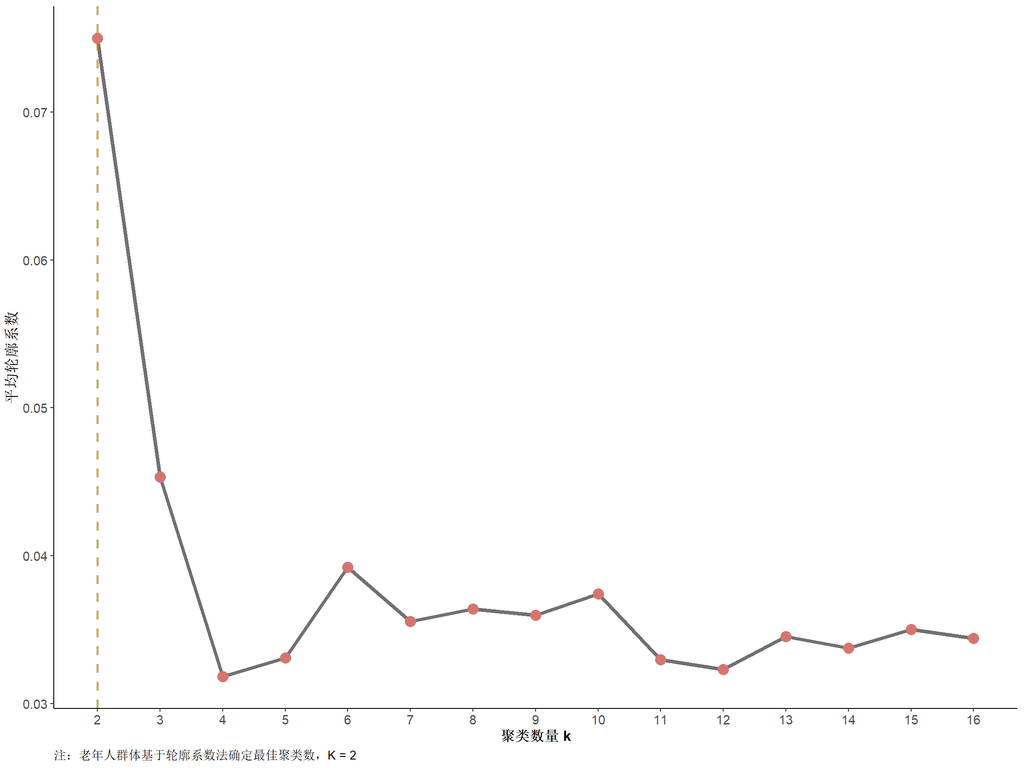

### 3.4 执行K-means聚类

使用自动选择的最佳k值执行K-means聚类，并将聚类标签与原始数据绑定。

### 3.5 聚类结果分析

分析老年人群体的聚类结果，生成特征剖面表格，展示不同聚类的特征差异。

老年人群体聚类特征剖面

K-means聚类方法

| 特征 | 1 | 2 |
| --- | --- | --- |
| 样本量 | 312.000 | 407.000 |
| 问卷总分_E | 57.494 | 76.376 |
| 性别_男_1_1_E | 0.375 | 0.376 |
| 年龄_60-64岁_1_2_1_E | 0.317 | 0.283 |
| 年龄_65-74岁_1_2_2_E | 0.391 | 0.369 |
| 年龄_75-84岁_1_2_3_E | 0.196 | 0.224 |
| 年龄_85岁及以上_1_2_4_E | 0.096 | 0.125 |
| 健康状况_失能程度_1_3_E | 1.478 | 1.602 |
| 居住行政区_和平区_1_4_1_E | 0.192 | 0.219 |
| 居住行政区_南开区_1_4_2_E | 0.208 | 0.241 |
| 居住行政区_河北区_1_4_3_E | 0.212 | 0.155 |
| 居住行政区_河东区_1_4_4_E | 0.128 | 0.106 |
| 居住行政区_河西区_1_4_5_E | 0.189 | 0.179 |
| 居住行政区_红桥区_1_4_6_E | 0.071 | 0.101 |
| 养老居住场景_居家独居_1_5_1_E | 0.580 | 0.531 |
| 养老居住场景_居家同住_1_5_2_E | 0.311 | 0.337 |
| 养老居住场景_社区养老_1_5_3_E | 0.058 | 0.074 |
| 养老居住场景_养老机构_1_5_4_E | 0.051 | 0.059 |
| 居家跌倒经历_有_1_6_E | 0.564 | 0.563 |
| 已装扶手_是_1_7_E | 0.314 | 0.278 |
| 扶手安装场景_卫生间_2_1_1_E | 0.891 | 0.899 |
| 扶手安装场景_床边_2_1_2_E | 0.404 | 0.391 |
| 扶手安装场景_楼道_2_1_3_E | 0.772 | 0.801 |
| 扶手安装场景_阳台_2_1_4_E | 0.503 | 0.528 |
| 扶手安装场景_其他_2_1_5_E | 0.231 | 0.221 |
| 扶手偏好类型_基础不锈钢_2_2_1_E | 0.157 | 0.201 |
| 扶手偏好类型_可折叠_2_2_2_E | 0.244 | 0.251 |
| 扶手偏好类型_防滑_2_2_3_E | 0.388 | 0.324 |
| 扶手偏好类型_智能预警_2_2_4_E | 0.112 | 0.113 |
| 扶手偏好类型_其他_2_2_5_E | 0.099 | 0.111 |
| 可接受价格_100元以内_2_3_1_E | 0.244 | 0.346 |
| 可接受价格_100-300元_2_3_2_E | 0.410 | 0.361 |
| 可接受价格_300-500元_2_3_3_E | 0.157 | 0.172 |
| 可接受价格_500元以上_2_3_4_E | 0.064 | 0.044 |
| 可接受价格_无所谓_2_3_5_E | 0.125 | 0.076 |
| 补贴期望_提高力度_2_4_1_E | 0.606 | 0.634 |
| 补贴期望_简化流程_2_4_2_E | 0.516 | 0.536 |
| 补贴期望_差异化补贴_2_4_3_E | 0.436 | 0.413 |
| 补贴期望_社区代办_2_4_4_E | 0.279 | 0.314 |
| 补贴期望_其他_2_4_5_E | 0.138 | 0.125 |
| 风险收益_3_1_1_E | 3.250 | 4.221 |
| 风险收益_3_1_2_E | 3.346 | 4.182 |
| 风险收益_3_1_3_E | 3.346 | 4.209 |
| 风险收益_3_1_4_E | 3.260 | 4.263 |
| 社会支持_3_2_1_E | 3.112 | 3.907 |
| 社会支持_3_2_2_E | 3.045 | 4.034 |
| 社会支持_3_2_3_E | 3.096 | 3.975 |
| 社会支持_3_2_4_E | 3.170 | 4.044 |
| 政策适配_3_3_1_E | 2.923 | 3.919 |
| 政策适配_3_3_2_E | 2.984 | 3.934 |
| 政策适配_3_3_3_E | 2.869 | 3.961 |
| 政策适配_3_3_4_E | 2.965 | 3.963 |
| 生活依赖_3_4_1_E | 2.869 | 3.776 |
| 生活依赖_3_4_2_E | 2.814 | 3.713 |
| 生活依赖_3_4_3_E | 2.853 | 3.816 |
| 生活依赖_3_4_4_E | 2.888 | 3.740 |
| 使用意愿_3_5_1_E | 2.981 | 4.201 |
| 使用意愿_3_5_2_E | 2.875 | 4.253 |
| 使用意愿_3_5_3_E | 2.849 | 4.265 |

### 4. 导出聚类结果

将聚类标签导出为CSV文件，方便后续分析和使用。

### 5. 聚类结果可视化

可视化聚类结果和轮廓系数，直观展示聚类效果。

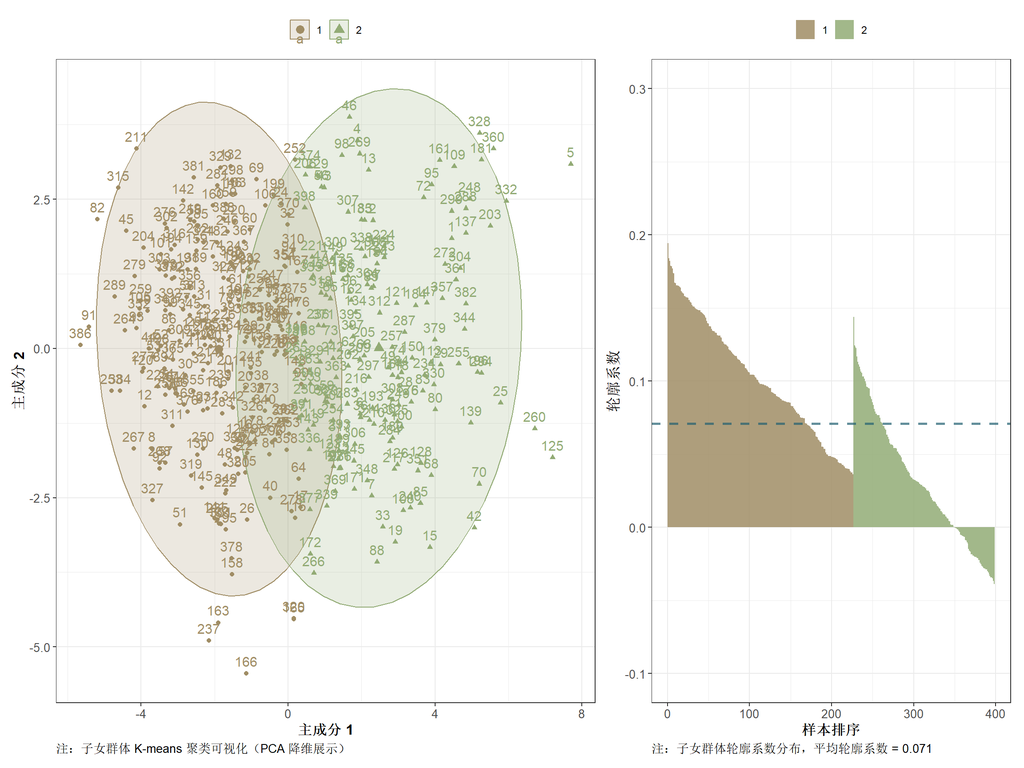

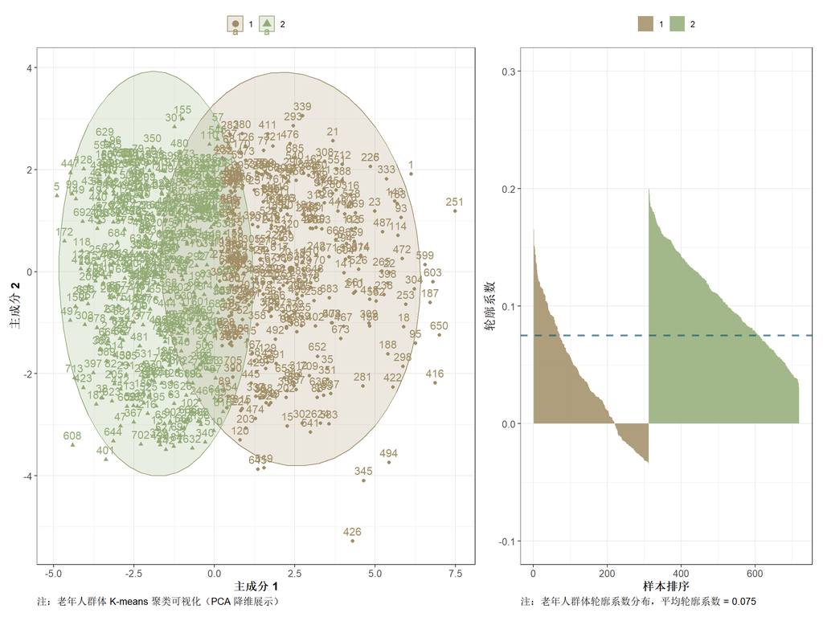